# Weight Loss 7 Assignment

### Find Residuals (Difference from observed values and mean)

```r
Resid <- Month7Loss - Fit
# Put them all together
cbind(Month7Loss, Fit, Resid)
```

```
##       Month7Loss      Fit       Resid
##  [1,]       -2.0 4.638889  -6.6388889
##  [2,]        7.0 4.638889   2.3611111
##  [3,]       19.5 4.638889  14.8611111
##  [4,]       -0.5 4.638889  -5.1388889
##  [5,]       -1.5 4.638889  -6.1388889
##  [6,]      -10.0 4.638889 -14.6388889
##  [7,]        0.5 4.638889  -4.1388889
##  [8,]        5.0 4.638889   0.3611111
##  [9,]        8.5 4.638889   3.8611111
## [10,]       18.0 4.638889  13.3611111
## [11,]       16.0 4.638889  11.3611111
## [12,]       -9.0 4.638889 -13.6388889
## [13,]        4.5 4.638889  -0.1388889
## [14,]       23.5 4.638889  18.8611111
```

[output cut: 19 more lines]

We already have t-statistic, but we can also calculate it manually

```r
sdc <- sd(Month7Loss[Group == "Control"])
sdi <- sd(Month7Loss[Group == "Incentive"])
nc <- length(Month7Loss[Group == "Control"])
ni <- length(Month7Loss[Group == "Incentive"])
t.stat <- (mu_control - mu_incentive) / sqrt(sdc^2 / nc + sdi^2 / ni)
```

### Check the Residuals

The qqnorm() function computes a normal probability plot

The qqline() function adds a reference line to this plot to help assess the straightness of the normal plot

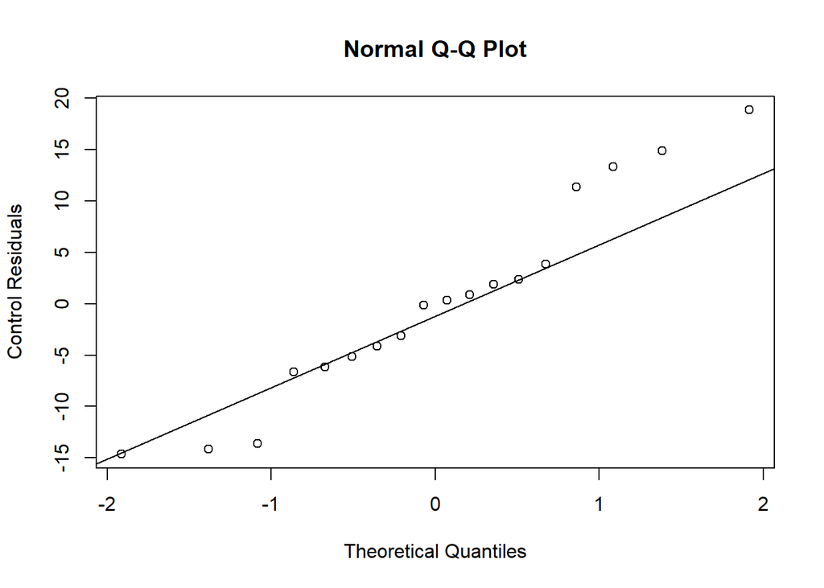

```r
qqnorm(Resid[Group == "Control"], ylab = "Control Residuals")
qqline(Resid[Group == "Control"])
```

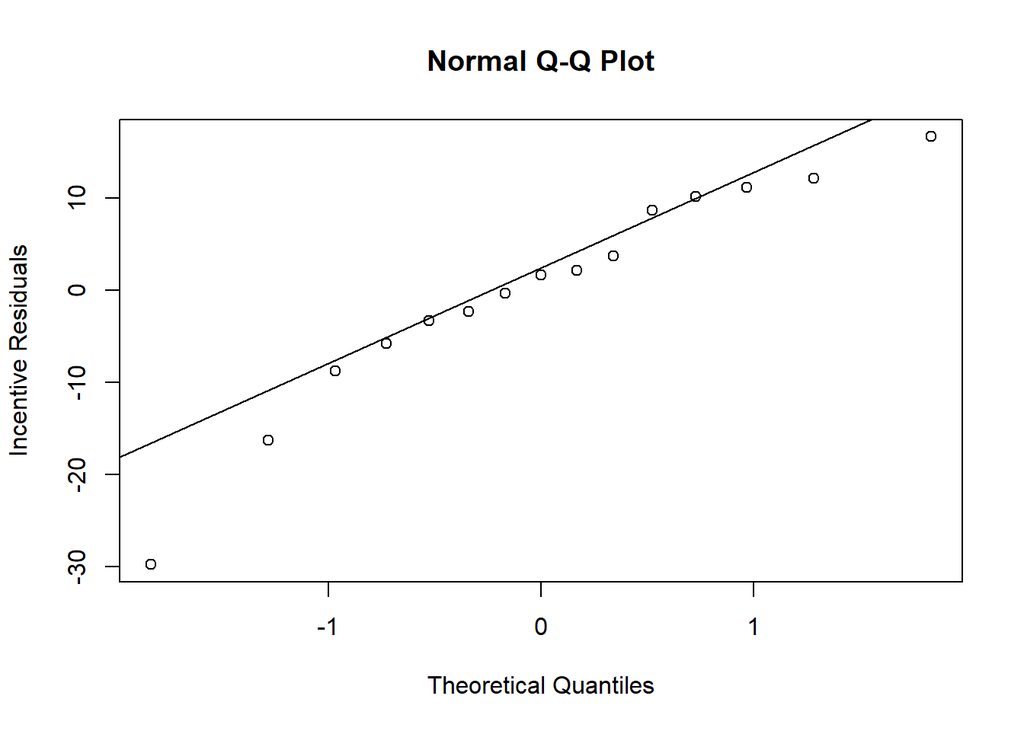

```r
qqnorm(Resid[Group == "Incentive"], ylab = "Incentive Residuals")
qqline(Resid[Group == "Incentive"])
```

### Effect size

The effect size is the ratio of observed differences (differences in means) to the standard deviation for person-to-person differences (pooled sd) `=(abs(mu1 - mu2))/(pooled sd)`

```r
# numerator
num <- abs(mu_control - mu_incentive)
# denominator
den <- sqrt(((nc - 1) * sdc^2 + (ni - 1) * sdi^2) / (nc + ni - 2))
effect <- num / den
```